[O’Hara on GitHub](https://github.com/oharac)

# Compare spp based impacts to habitat-based impacts

Compiled on Sun Apr 24 20:21:21 2022 by ohara

```r
knitr::opts_chunk$set(echo = TRUE, message = FALSE, warning = FALSE, fig.height = 4, fig.width = 8)

library(raster)
library(oharac)
library(data.table)
library(tidyverse)
library(here)
source(here('common_fxns.R'))
```

# 1 Summary

Gather CHI map from Halpern et al. 2019, reproject to CRS/res of current analysis. Create maps comparing unweighted spp CHI, FV-weighted spp CHI, and habitat-based CHI.

# 2 Data

See scripts in `2_process_vuln_and_impacts` folder. The habitat-based impact maps are taken from Halpern et al. (2019) - Recent Pace of Change paper: https://knb.ecoinformatics.org/view/doi:10.5063/F12B8WBS. These have been aggregated and reprojected to the native CRS/res of the current analysis.

# 3 Methods

## 3.1 Load rasters

```r
ocean_a <- raster(here('_spatial/ocean_area_mol.tif'))
neritic <- raster(here('_spatial/bathy_mol_neritic.tif'))
coastal <- raster(here('_spatial/coastal_3nmi_area_mol.tif'))
npp_pel <- raster(here_anx('stressors/fishing/npp',
                            'log_npp_present_surf_gf_mol.tif'))

nspp <- raster(here('_output/nspp_maps/nspp_in_unwt_vuln.tif'))

imp_hab_fs <- list.files(here('_data/chi_halpern_2019'),
                         pattern = '.tif', full.names = TRUE)
imp_hab_stack <- stack(imp_hab_fs[!str_detect(imp_hab_fs, 'cumulative')])

imp_spp_unwt_stack <- list.files(here('_output/impact_maps/impact_maps_unweighted'),
                              pattern = 'mean.tif', full.names = TRUE) %>%
  stack() %>%
  setNames(str_remove_all(names(.), 'impact_unwt_|_x_.+|_mean.*'))

imp_spp_fvwt_stack <- list.files(here('_output/impact_maps/impact_maps_fv_weighted'),
                              pattern = 'mean.tif', full.names = TRUE) %>%
  stack() %>%
  setNames(str_remove_all(names(.), 'impact_fvwt_|_x_.+|_mean.*'))
```

## 3.2 Fishing impacts

Assemble dataframe of values from CHI 2019 fishing layers, then join with weighted and unweighted biomass removal and bycatch layers from spp CHI.

The five fishing layers from CHI 2019 will be summed to create a single fishing layer; similarly the biomass removal and bycatch (and maybe fishing benthic destruction?).

For these (and other plots) using a transformation to better compare low values, e.g., $\sqrt[4]x$

```r
flatten_layers <- function(r, lyrs) {
  raster::subset(r, lyrs) %>%
    calc(sum, na.rm = TRUE) %>%
    mask(ocean_a)
}
quick_map <- function(r, main = NULL, xfm = identity) {
  r <- xfm(r)
  p <- 'viridis'
  plot(r, col = hcl.colors(n = 50, palette = p),
       main = main,
       axes = FALSE)
}
quick_map_divergent <- function(r, main = NULL) {
  p <- 'Red-Green'
  z_max <- max(maxValue(r), -minValue(r))
  z <- c(-z_max, z_max)
  plot(r, col = hcl.colors(n = 50, palette = p),
       main = main,
       axes = FALSE, zlim = z)
}
```

```r
hab_fish_rast <- flatten_layers(imp_hab_stack, which(str_detect(names(imp_hab_stack), 'fishing')))
spp_fish_unwt_rast <- flatten_layers(imp_spp_unwt_stack, c('biomass_removal', 'bycatch'))
spp_fish_fvwt_rast <- flatten_layers(imp_spp_fvwt_stack, c('biomass_removal', 'bycatch'))

# quick_map(hab_fish_rast^.25, main = '4th root Hab-based fishing')
# quick_map(spp_fish_unwt_rast^.25, main = '4th root Spp-based fishing, unweighted')
# quick_map(spp_fish_fvwt_rast^.25, main = '4th root Spp-based fishing, FV-weighted')
```

```r
fish_impacts_df <- data.frame(hab = values(hab_fish_rast),
                              unwt = values(spp_fish_unwt_rast),
                              fvwt = values(spp_fish_fvwt_rast),
                              unwt_dest = values(imp_spp_unwt_stack$fishing_benthic_dest),
                              fvwt_dest = values(imp_spp_fvwt_stack$fishing_benthic_dest)) %>%
  filter(!is.na(unwt))

fish_lm_fvwt <- lm(hab ~ fvwt + fvwt_dest, data = fish_impacts_df)
fish_lm_unwt <- lm(hab ~ unwt + unwt_dest, data = fish_impacts_df)
# summary(fish_lm_fvwt)
# summary(fish_lm_unwt)
```

## 3.3 Climate impacts

### 3.3.1 SST extremes impacts

SST extremes layer for this analysis is analogous to the SST impacts from Halpern et al 2019.

```r
hab_sst <- imp_hab_stack$sst_extremes
unwt_sst <- imp_spp_unwt_stack$sst_extremes
fvwt_sst <- imp_spp_fvwt_stack$sst_extremes

# quick_map(hab_sst^.25, main = '4th root Hab-based SST extremes')
# quick_map(unwt_sst^.25, main = '4th root Spp-based SST extremes, unweighted')
# quick_map(fvwt_sst^.25, main = '4th root Spp-based SST extremes, FV-weighted')
```

```r
sst_impacts_df <- data.frame(hab = values(hab_sst),
                             unwt = values(unwt_sst),
                             fvwt = values(fvwt_sst)) %>%
  filter(!is.na(unwt))

sst_lm_fvwt <- lm(hab ~ fvwt, data = sst_impacts_df)
sst_lm_unwt <- lm(hab ~ unwt, data = sst_impacts_df)
# summary(sst_lm_fvwt)
# summary(sst_lm_unwt)
```

### 3.3.2 OA impacts

```r
hab_oa <- imp_hab_stack$ocean_acidification
unwt_oa <- imp_spp_unwt_stack$ocean_acidification
fvwt_oa <- imp_spp_fvwt_stack$ocean_acidification

# quick_map(hab_oa^.5, main = 'Square root Hab-based OA')
# quick_map(unwt_oa^.5, main = 'Square root Spp-based OA, unweighted')
# quick_map(fvwt_oa^.5, main = 'Square root Spp-based OA, FV-weighted')
```

```r
oa_impacts_df <- data.frame(hab = values(hab_oa),
                            unwt = values(unwt_oa),
                            fvwt = values(fvwt_oa)) %>%
  filter(!is.na(unwt))

oa_lm_fvwt <- lm(hab ~ fvwt, data = oa_impacts_df)
oa_lm_unwt <- lm(hab ~ unwt, data = oa_impacts_df)
# summary(oa_lm_fvwt)
# summary(oa_lm_unwt)
```

### 3.3.3 SLR impacts

```r
hab_sea_level_rise <- imp_hab_stack$sea_level_rise %>% mask(coastal)
unwt_sea_level_rise <- imp_spp_unwt_stack$sea_level_rise %>% mask(coastal)
fvwt_sea_level_rise <- imp_spp_fvwt_stack$sea_level_rise %>% mask(coastal)

# quick_map(hab_sea_level_rise^.5, main = 'Square root Hab-based sea_level_rise')
# quick_map(unwt_sea_level_rise^.5, main = 'Square root Spp-based sea_level_rise, unweighted')
# quick_map(fvwt_sea_level_rise^.5, main = 'Square root Spp-based sea_level_rise, FV-weighted')
```

```r
sea_level_rise_impacts_df <- data.frame(hab = values(hab_sea_level_rise),
                            unwt = values(unwt_sea_level_rise),
                            fvwt = values(fvwt_sea_level_rise)) %>%
  filter(!is.na(unwt))

sea_level_rise_lm_fvwt <- lm(hab ~ fvwt, data = sea_level_rise_impacts_df)
sea_level_rise_lm_unwt <- lm(hab ~ unwt, data = sea_level_rise_impacts_df)
# summary(sea_level_rise_lm_fvwt)
# summary(sea_level_rise_lm_unwt)
```

## 3.4 Shipping impacts

```r
hab_shipping <- imp_hab_stack$shipping
unwt_shipping <- imp_spp_unwt_stack$shipping_large
fvwt_shipping <- imp_spp_fvwt_stack$shipping_large

# quick_map(hab_shipping^.5, main = 'Square root Hab-based shipping')
# quick_map(unwt_shipping^.5, main = 'Square root Spp-based shipping, unweighted')
# quick_map(fvwt_shipping^.5, main = 'Square root Spp-based shipping, FV-weighted')
```

```r
shipping_impacts_df <- data.frame(hab = values(hab_shipping),
                            unwt = values(unwt_shipping),
                            fvwt = values(fvwt_shipping)) %>%
  filter(!is.na(unwt))

shipping_lm_fvwt <- lm(hab ~ fvwt, data = shipping_impacts_df)
shipping_lm_unwt <- lm(hab ~ unwt, data = shipping_impacts_df)
# summary(shipping_lm_fvwt)
# summary(shipping_lm_unwt)
```

## 3.5 Land-based impacts

### 3.5.1 Direct human impacts

```r
hab_direct_human <- imp_hab_stack$direct_human %>% mask(coastal)
unwt_direct_human <- imp_spp_unwt_stack$direct_human %>% mask(coastal)
fvwt_direct_human <- imp_spp_fvwt_stack$direct_human %>% mask(coastal)

# quick_map(hab_direct_human^.5, main = 'Square root Hab-based direct_human')
# quick_map(unwt_direct_human^.5, main = 'Square root Spp-based direct_human, unweighted')
# quick_map(fvwt_direct_human^.5, main = 'Square root Spp-based direct_human, FV-weighted')
```

```r
direct_human_impacts_df <- data.frame(hab = values(hab_direct_human),
                            unwt = values(unwt_direct_human),
                            fvwt = values(fvwt_direct_human)) %>%
  filter(!is.na(unwt))

direct_human_lm_fvwt <- lm(hab ~ fvwt, data = direct_human_impacts_df)
direct_human_lm_unwt <- lm(hab ~ unwt, data = direct_human_impacts_df)
# summary(direct_human_lm_fvwt)
# summary(direct_human_lm_unwt)
```

### 3.5.2 Nutrient pollution impacts

```r
hab_nutrient <- imp_hab_stack$nutrient_pollution %>% mask(coastal)
unwt_nutrient <- imp_spp_unwt_stack$nutrient %>% mask(coastal)
fvwt_nutrient <- imp_spp_fvwt_stack$nutrient %>% mask(coastal)

# quick_map(hab_nutrient^.5, main = 'Square root Hab-based nutrient')
# quick_map(unwt_nutrient^.5, main = 'Square root Spp-based nutrient, unweighted')
# quick_map(fvwt_nutrient^.5, main = 'Square root Spp-based nutrient, FV-weighted')
```

```r
nutrient_impacts_df <- data.frame(hab = values(hab_nutrient),
                            unwt = values(unwt_nutrient),
                            fvwt = values(fvwt_nutrient)) %>%
  filter(!is.na(unwt))

nutrient_lm_fvwt <- lm(hab ~ fvwt, data = nutrient_impacts_df)
nutrient_lm_unwt <- lm(hab ~ unwt, data = nutrient_impacts_df)
# summary(nutrient_lm_fvwt)
# summary(nutrient_lm_unwt)
```

### 3.5.3 Light pollution impacts

```r
hab_light_pollution <- imp_hab_stack$light_pollution %>% mask(coastal)
unwt_light_pollution <- imp_spp_unwt_stack$light %>% mask(coastal)
fvwt_light_pollution <- imp_spp_fvwt_stack$light %>% mask(coastal)

# quick_map(hab_light_pollution^.5, main = 'Square root Hab-based light_pollution')
# quick_map(unwt_light_pollution^.5, main = 'Square root Spp-based light_pollution, unweighted')
# quick_map(fvwt_light_pollution^.5, main = 'Square root Spp-based light_pollution, FV-weighted')
```

```r
light_pollution_impacts_df <- data.frame(hab = values(hab_light_pollution),
                            unwt = values(unwt_light_pollution),
                            fvwt = values(fvwt_light_pollution)) %>%
  filter(!is.na(unwt))

light_pollution_lm_fvwt <- lm(hab ~ fvwt, data = light_pollution_impacts_df)
light_pollution_lm_unwt <- lm(hab ~ unwt, data = light_pollution_impacts_df)
# summary(light_pollution_lm_fvwt)
# summary(light_pollution_lm_unwt)
```

## 3.6 Summarize R<sup>2</sup> values

```r
fvwt_models <- ls(pattern = 'lm_fvwt')
unwt_models <- ls(pattern = 'lm_unwt')
mdl_df <- lapply(c(fvwt_models, unwt_models),
                 FUN = function(m) {
                   x <- broom::tidy(get(m)) %>%
                     mutate(term = str_remove_all(tolower(term), '\\(|\\)'),
                            mdl = m,
                            adj_r_sq = summary(get(m))$adj.r.squared)
                 }) %>%
  bind_rows() %>%
  mutate(stressor = str_remove(mdl, '_lm.+'),
         wt  = str_extract(mdl, 'fvwt|unwt')) %>%
  select(stressor, term, estimate, statistic, adj_r_sq) %>%
  filter(term != 'intercept') %>%
  mutate(across(where(is.numeric), ~round(.x, 4)))

DT::datatable(mdl_df %>% arrange(desc(adj_r_sq)))
```

|  | stressor | term | estimate | statistic | adj_r_sq |
| --- | --- | --- | --- | --- | --- |
| 1 | light_pollution | fvwt | 1.2609 | 437.6841 | 0.6224 |
| 2 | light_pollution | unwt | 1.1639 | 435.8836 | 0.6205 |
| 3 | oa | fvwt | 4.4759 | 1906.8386 | 0.4974 |
| 4 | oa | unwt | 5.1152 | 1502.3506 | 0.3806 |
| 5 | direct_human | fvwt | 7.1843 | 264.2429 | 0.3753 |
| 6 | nutrient | fvwt | 2.5311 | 240.3298 | 0.332 |
| 7 | direct_human | unwt | 6.595 | 239.7734 | 0.331 |
| 8 | nutrient | unwt | 2.4826 | 235.9994 | 0.324 |
| 9 | shipping | fvwt | 7.6683 | 968.7281 | 0.204 |
| 10 | shipping | unwt | 3.9787 | 796.8495 | 0.1478 |

[output cut: 8 more lines]

Some stressors show a rather poor correlation between the two projects. The stressor layers *should* be similar, but the mean (unweighted or fv-weighted) vulnerability of all spp present in a cell may be quite different from the vulnerability score assigned for the representative habitats in the same cell. To explore this further, compare the raw stressor layers between the two projects for:

- Sea level rise
- Sea surface temperature extremes
- Shipping

For fishing, the methods from 2019 aggregated geartypes and rescaled the various fishing stressors across five categories, while methods from this analysis independently applied fishing catch across taxonomic groups irrespective of gear types (though NPP rescaling was tied to water column position of gear type). Because of these quite different methods, we can compare the original data from Watson (2018) for the assessment years in Halpern 2019 vs the assessment years used in this assessment.

For comparison, we should also compare other stressor layers that we expect to be well correlated.

### 3.6.1 Compare SST stressors

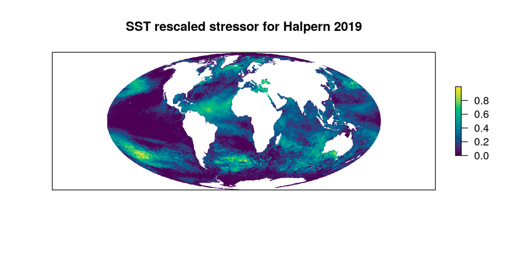

```r
sst_str_hab <- raster(here('_data/chi_halpern_2019/stressors',
                           'sst_extremes_stressor_rescaled.tif'))
sst_str_spp <- raster(here('_data/stressors_mol/sst_extremes_2020.tif'))

quick_map(sst_str_hab, main = 'SST rescaled stressor for Halpern 2019')
```

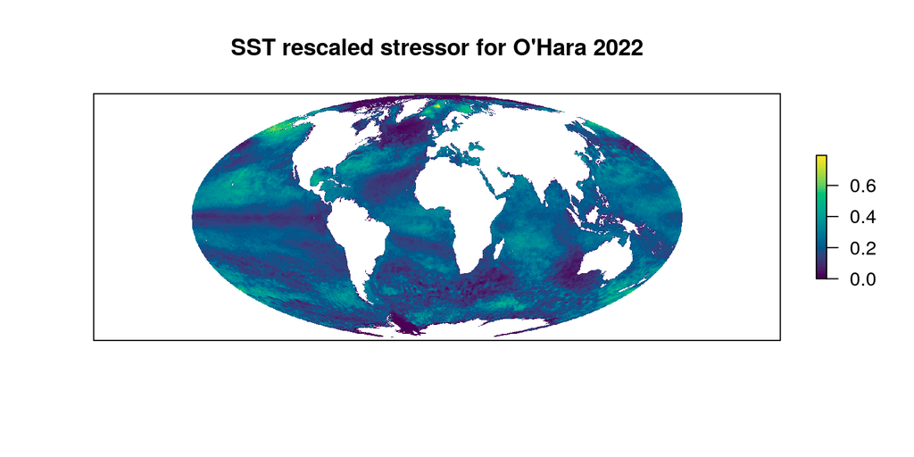

```r
quick_map(sst_str_spp, main = 'SST rescaled stressor for O\'Hara 2022')
```

```r
sst_strs_df <- data.frame(hab = values(sst_str_hab),
                          spp = values(sst_str_spp)) %>%
  filter(!is.na(spp))

sst_str_lm <- lm(hab ~ spp, data = sst_strs_df)
summary(sst_str_lm)
```

```
##
## Call:
## lm(formula = hab ~ spp, data = sst_strs_df)
##
## Residuals:
##     Min      1Q  Median      3Q     Max
## -0.2332 -0.1588 -0.0247  0.1058  0.7952
##
## Coefficients:
##               Estimate Std. Error t value Pr(>|t|)
## (Intercept)  0.2332294  0.0002342   995.7   <2e-16 ***
## spp         -0.1264640  0.0010207  -123.9   <2e-16 ***
## ---
## Signif. codes:  0 '***' 0.001 '**' 0.01 '*' 0.05 '.' 0.1 ' ' 1
##
## Residual standard error: 0.1801 on 3677944 degrees of freedom
##   (6294 observations deleted due to missingness)
## Multiple R-squared:  0.004156,   Adjusted R-squared:  0.004156
## F-statistic: 1.535e+04 on 1 and 3677944 DF,  p-value: < 2.2e-16
```

Many of the hottest parts of the oceans according to 2013 data match with cooler parts in 2020, and vice versa… wth? We used a different threshold for extremes based on MHW literature (for Mel’s MARISCO project), but that should not make such a difference. If available, compare data from that project from 2013 to the layer from Halpern et al. 2019.

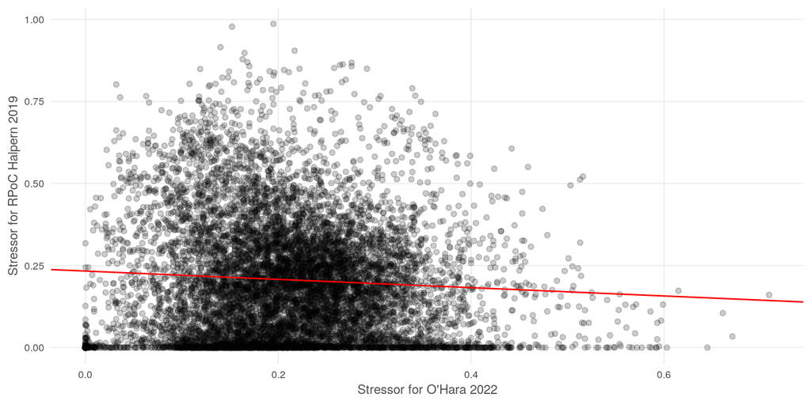

```r
sst_2013_file <- here_anx('../../stressors_2021/_dataprep/SST_past_present/final_extreme',
                            'sst_exceeds_90quant_2016-2020.tif')
ggplot(sst_strs_df %>% sample_n(10000), aes(x = spp, y = hab)) +
  geom_point(alpha = .2) +
  geom_abline(intercept = coef(sst_str_lm)[1], slope = coef(sst_str_lm)[2], color = 'red') +
  theme_ohara() +
  labs(y = 'Stressor for RPoC Halpern 2019', x = 'Stressor for O\'Hara 2022')
```

### 3.6.2 Compare SLR stressors

Was SLR in 2019 significantly different in pattern from 2013?

```r
coastal <- raster(here('_spatial/coastal_3nmi_area_mol.tif'))
slr_str_hab <- raster(here('_data/chi_halpern_2019/stressors',
                           'sea_level_rise_stressor_rescaled.tif')) %>%
  mask(coastal)
slr_str_spp <- raster(here('_data/stressors_mol/sea_level_rise_2019.tif')) %>%
  mask(coastal)

# quick_map(slr_str_hab, main = 'SLR rescaled stressor for Halpern 2019')
# quick_map(slr_str_spp, main = 'SLR rescaled stressor for O\'Hara 2022')
```

```r
slr_strs_df <- data.frame(hab = values(slr_str_hab),
                          spp = values(slr_str_spp)) %>%
  filter(!is.na(spp))

slr_str_lm <- lm(hab ~ spp, data = slr_strs_df)
summary(slr_str_lm)
```

```
##
## Call:
## lm(formula = hab ~ spp, data = slr_strs_df)
##
## Residuals:
##      Min       1Q   Median       3Q      Max
## -0.19151 -0.05364 -0.00318  0.04745  0.81354
##
## Coefficients:
##               Estimate Std. Error t value Pr(>|t|)
## (Intercept)  0.1915051  0.0004317  443.59   <2e-16 ***
## spp         -0.0254629  0.0021311  -11.95   <2e-16 ***
## ---
## Signif. codes:  0 '***' 0.001 '**' 0.01 '*' 0.05 '.' 0.1 ' ' 1
##
## Residual standard error: 0.08497 on 113293 degrees of freedom
##   (5306 observations deleted due to missingness)
## Multiple R-squared:  0.001258,   Adjusted R-squared:  0.00125
## F-statistic: 142.8 on 1 and 113293 DF,  p-value: < 2.2e-16
```

### 3.6.3 Compare shipping stressors

This analysis uses a different source for shipping data, based on AIS tracking, and excluding small ships, so rather weak correlation is not super surprising.

```r
shipping_str_hab <- raster(here('_data/chi_halpern_2019/stressors',
                           'shipping_stressor_rescaled.tif'))
shipping_str_spp <- raster(here('_data/stressors_mol/shipping_large_2021.tif'))

# quick_map(shipping_str_hab, main = 'Shipping rescaled stressor for Halpern 2019')
# quick_map(shipping_str_spp, main = 'Shipping rescaled stressor for O\'Hara 2022')
```

```r
shipping_strs_df <- data.frame(hab = values(shipping_str_hab),
                               spp = values(shipping_str_spp)) %>%
  filter(!is.na(spp))

shipping_str_lm <- lm(hab ~ spp, data = shipping_strs_df)
summary(shipping_str_lm)
```

```
##
## Call:
## lm(formula = hab ~ spp, data = shipping_strs_df)
##
## Residuals:
##      Min       1Q   Median       3Q      Max
## -1.34864 -0.11870 -0.04550  0.08297  0.85618
##
## Coefficients:
##              Estimate Std. Error t value Pr(>|t|)
## (Intercept) 1.243e-01  7.383e-05    1684   <2e-16 ***
## spp         1.227e+00  1.140e-03    1076   <2e-16 ***
## ---
## Signif. codes:  0 '***' 0.001 '**' 0.01 '*' 0.05 '.' 0.1 ' ' 1
##
## Residual standard error: 0.1385 on 3661559 degrees of freedom
##   (9868 observations deleted due to missingness)
## Multiple R-squared:  0.2402, Adjusted R-squared:  0.2402
## F-statistic: 1.158e+06 on 1 and 3661559 DF,  p-value: < 2.2e-16
```

## 3.7 Check seemingly non-problematic stressors

### 3.7.1 Compare light pollution stressors

```r
light_str_hab <- raster(here('_data/chi_halpern_2019/stressors',
                             'light_pollution_stressor_rescaled.tif')) %>%
  mask(coastal)
light_str_spp <- raster(here('_data/stressors_mol/light_2018.tif')) %>%
  mask(coastal)

# quick_map(light_str_hab, main = 'light pollution rescaled stressor for Halpern 2019')
# quick_map(light_str_spp, main = 'light pollution rescaled stressor for O\'Hara 2022')
```

```r
light_strs_df <- data.frame(hab = values(light_str_hab),
                            spp = values(light_str_spp)) %>%
  filter(!is.na(spp))

light_str_lm <- lm(hab ~ spp, data = light_strs_df)
summary(light_str_lm)
```

```
##
## Call:
## lm(formula = hab ~ spp, data = light_strs_df)
##
## Residuals:
##      Min       1Q   Median       3Q      Max
## -0.38949 -0.00326 -0.00326 -0.00326  0.70667
##
## Coefficients:
##              Estimate Std. Error t value Pr(>|t|)
## (Intercept) 0.0032647  0.0001637   19.94   <2e-16 ***
## spp         0.3862295  0.0007390  522.65   <2e-16 ***
## ---
## Signif. codes:  0 '***' 0.001 '**' 0.01 '*' 0.05 '.' 0.1 ' ' 1
##
## Residual standard error: 0.05281 on 116436 degrees of freedom
##   (5381 observations deleted due to missingness)
## Multiple R-squared:  0.7011, Adjusted R-squared:  0.7011
## F-statistic: 2.732e+05 on 1 and 116436 DF,  p-value: < 2.2e-16
```

### 3.7.2 Compare direct human stressors

This seems lower correlation than it should (though still 40%)… is there some difference in methods e.g. log transform or additional masking going on?

```r
direct_human_str_hab <- raster(here('_data/chi_halpern_2019/stressors',
                             'direct_human_stressor_rescaled.tif')) %>%
  mask(coastal)
direct_human_str_spp <- raster(here('_data/stressors_mol/direct_human_2020.tif')) %>%
  mask(coastal)

# quick_map(direct_human_str_hab, main = 'direct_human rescaled stressor for Halpern 2019')
# quick_map(direct_human_str_spp, main = 'direct_human rescaled stressor for O\'Hara 2022')
```

```r
direct_human_strs_df <- data.frame(hab = values(direct_human_str_hab),
                            spp = values(direct_human_str_spp)) %>%
  filter(!is.na(spp))

direct_human_str_lm <- lm(hab ~ spp, data = direct_human_strs_df)
summary(direct_human_str_lm)
```

```
##
## Call:
## lm(formula = hab ~ spp, data = direct_human_strs_df)
##
## Residuals:
##      Min       1Q   Median       3Q      Max
## -0.50850 -0.02594 -0.02542  0.00707  0.55977
##
## Coefficients:
##              Estimate Std. Error t value Pr(>|t|)
## (Intercept) 0.0259350  0.0002576   100.7   <2e-16 ***
## spp         0.4877984  0.0017453   279.5   <2e-16 ***
## ---
## Signif. codes:  0 '***' 0.001 '**' 0.01 '*' 0.05 '.' 0.1 ' ' 1
##
## Residual standard error: 0.07869 on 116436 degrees of freedom
##   (6324 observations deleted due to missingness)
## Multiple R-squared:  0.4015, Adjusted R-squared:  0.4015
## F-statistic: 7.812e+04 on 1 and 116436 DF,  p-value: < 2.2e-16
```

### 3.7.3 Compare nutrient pollution stressors

This analysis includes additional nutrient pollutants, including wastewater and aquaculture along with agriculture, so not as strong a correlation but still solid.

```r
nutrient_str_hab <- raster(here('_data/chi_halpern_2019/stressors',
                             'nutrient_pollution_stressor_rescaled.tif')) %>%
  mask(coastal)
nutrient_str_spp <- raster(here('_data/stressors_mol/nutrient_2020.tif')) %>%
  mask(coastal)

# quick_map(nutrient_str_hab, main = 'nutrient pollution rescaled stressor for Halpern 2019')
# quick_map(nutrient_str_spp, main = 'nutrient pollution rescaled stressor for O\'Hara 2022')
```

```r
nutrient_strs_df <- data.frame(hab = values(nutrient_str_hab),
                            spp = values(nutrient_str_spp)) %>%
  filter(!is.na(spp))

nutrient_str_lm <- lm(hab ~ spp, data = nutrient_strs_df)
summary(nutrient_str_lm)
```

```
##
## Call:
## lm(formula = hab ~ spp, data = nutrient_strs_df)
##
## Residuals:
##      Min       1Q   Median       3Q      Max
## -0.62546 -0.06593 -0.06227  0.01094  0.93407
##
## Coefficients:
##              Estimate Std. Error t value Pr(>|t|)
## (Intercept) 0.0659263  0.0004667   141.3   <2e-16 ***
## spp         0.5595310  0.0022278   251.2   <2e-16 ***
## ---
## Signif. codes:  0 '***' 0.001 '**' 0.01 '*' 0.05 '.' 0.1 ' ' 1
##
## Residual standard error: 0.1505 on 116436 degrees of freedom
##   (5381 observations deleted due to missingness)
## Multiple R-squared:  0.3514, Adjusted R-squared:  0.3514
## F-statistic: 6.308e+04 on 1 and 116436 DF,  p-value: < 2.2e-16
```

### 3.7.4 Compare ocean acidification stressors

```r
oa_str_hab <- raster(here('_data/chi_halpern_2019/stressors',
                             'ocean_acidification_stressor_rescaled.tif'))
oa_str_spp <- raster(here('_data/stressors_mol/ocean_acidification_2020.tif'))

# quick_map(oa_str_hab, main = 'OA rescaled stressor for Halpern 2019')
# quick_map(oa_str_spp, main = 'OA rescaled stressor for O\'Hara 2022')
```

```r
oa_strs_df <- data.frame(hab = values(oa_str_hab),
                            spp = values(oa_str_spp)) %>%
  filter(!is.na(spp))

oa_str_lm <- lm(hab ~ spp, data = oa_strs_df)
summary(oa_str_lm)
```

```
##
## Call:
## lm(formula = hab ~ spp, data = oa_strs_df)
##
## Residuals:
##      Min       1Q   Median       3Q      Max
## -1.16079 -0.04766 -0.01204  0.03030  0.75487
##
## Coefficients:
##               Estimate Std. Error t value Pr(>|t|)
## (Intercept) -0.0481929  0.0001132  -425.8   <2e-16 ***
## spp          1.2089833  0.0003518  3436.2   <2e-16 ***
## ---
## Signif. codes:  0 '***' 0.001 '**' 0.01 '*' 0.05 '.' 0.1 ' ' 1
##
## Residual standard error: 0.09217 on 3338608 degrees of freedom
##   (345630 observations deleted due to missingness)
## Multiple R-squared:  0.7796, Adjusted R-squared:  0.7796
## F-statistic: 1.181e+07 on 1 and 3338608 DF,  p-value: < 2.2e-16
```